# Analysis of Air Quality Index in Allegheny County

Cailin De Zeeuw

October 14, 2022

## Allegheny County Air Quality Index

The Allegheny County Health Department regularly tracks air quality at sites throughout the county. Given the impact of air quality on public health and Western Pennsylvania’s industrial history, this data is useful for analyzing local air pollution levels and their potential health implications. Monitoring is also useful for determining compliance with federal air quality standards.

The data in this analysis was downloaded from the Western Pennsylvania Regional Data Center. (https://data.wprdc.org/dataset/allegheny-county-air-quality/resource/4ab1e23f-3262-4bd3-adbf-f72f0119108b?view_id=7d5cdd3a-a08e-4131-a528-41734c71f64c)

```r
#load Allegheny County AQI dataset
aqi.AC  <- read.csv("data/AQI.csv", stringsAsFactors = TRUE) #Air Quality Index in Allegheny County (AC)
str(aqi.AC)
```

```
## 'data.frame':    54689 obs. of  7 variables:
##  $ date           : Factor w/ 2470 levels "2016-01-01","2016-01-02",..: 1 1 1 1 1 1 1 1 1 1 ...
##  $ site           : Factor w/ 15 levels "Avalon","Clairton",..: 6 3 5 1 10 10 14 11 12 3 ...
##  $ parameter      : Factor w/ 13 levels "CO","NO2","NO2_500",..: 11 1 4 13 8 5 13 7 1 5 ...
##  $ index_value    : int  25 0 31 10 35 11 3 12 4 7 ...
##  $ description    : Factor w/ 4 levels "Good","Moderate",..: 1 1 1 1 1 1 1 1 1 1 ...
##  $ health_advisory: Factor w/ 7 levels "","Active children and adults, and people with respiratory disease, such as asthma, should reduce prolonged or hea"| __truncated__,..: 1 1 1 1 1 1 1 1 1 1 ...
##  $ health_effects : Factor w/ 7 levels "","Increased aggravation of heart or lung disease and premature mortality in people with cardiopulmonary disease a"| __truncated__,..: 1 1 1 1 1 1 1 1 1 1 ...
```

```r
#coercing dates to correct data structure
aqi.AC$date <- as.character(aqi.AC$date)
aqi.AC <- aqi.AC %>%
  mutate(date = as.Date(date, format="%Y-%m-%d"))

summary(aqi.AC)
```

```
##       date                           site         parameter      index_value
##  Min.   :2016-01-01   Parkway East     : 7343   SO2    :12042   Min.   :  0.0
##  1st Qu.:2017-09-16   North Braddock   : 5612   PM10   : 8940   1st Qu.:  6.0
##  Median :2019-05-06   Lawrenceville 2  : 4892   CO     : 7202   Median : 18.0
##  Mean   :2019-05-08   Liberty 2        : 4828   OZONE  : 7062   Mean   : 21.7
##  3rd Qu.:2020-12-20   Harrison Township: 4728   PM25T  : 6288   3rd Qu.: 33.0
##  Max.   :2022-10-05   South Fayette    : 4588   NO2    : 4858   Max.   :163.0
##                       (Other)          :22698   (Other): 8297
##                          description
##  Good                          :50203
##  Moderate                      : 4379
##  Unhealthy                     :    7
##  Unhealthy for Sensitive Groups:  100
##
##
##
##                                                                                                                                                          health_advisory
##                                                                                                                                                                  :50385
##  Active children and adults, and people with respiratory disease, such as asthma, should reduce prolonged or heavy outdoor exertion.                             :   21
##  People with asthma should consider limiting outdoor exertion.                                                                                                   :   14
##  People with heart or lung disease, older adults, and children should avoid prolonged or heavy exertion; everyone else should reduce prolonged or heavy exertion.:    7
##  People with heart or lung disease, older adults, and children should reduce prolonged or heavy exertion.                                                        :   65
##  Unusually sensitive people should consider reducing prolonged or heavy exertion.                                                                                : 3770
##  Unusually sensitive people should consider reducing prolonged or heavy outdoor exertion.                                                                        :  427
##                                                                                                                                                                                        health_effects
##                                                                                                                                                                                               :50385
##  Increased aggravation of heart or lung disease and premature mortality in people with cardiopulmonary disease and older adults; increased respiratory effects in general population.         :    7
##  Increasing likelihood of respiratory symptoms and breathing discomfort in active children and adults and people with respiratory disease, such as asthma.                                    :   21
##  Increasing likelihood of respiratory symptoms in sensitive individuals, aggravation of heart or lung disease and premature mortality in people with cardiopulmonary disease and older adults.:   65
##  Increasing likelihood of respiratory symptoms, such as chest tightness and breathing discomfort, in people with asthma.                                                                      :   14
##  Respiratory symptoms possible in unusually sensitive individuals, possible aggravation of heart or lung disease in people with cardiopulmonary disease and older adults.                     : 3770
##  Unusually sensitive individuals may experience respiratory symptoms.                                                                                                                         :  427
```

```r
unique(aqi.AC$site)
```

```
##  [1] Lawrenceville         Flag Plaza            Harrison Township
##  [4] Avalon                Lincoln               South Fayette
##  [7] North Braddock        Parkway East          Liberty 2
## [10] Lawrenceville 2       Glassport High Street Liberty
## [13] Clairton              West Mifflin          Pittsburgh
## 15 Levels: Avalon Clairton Flag Plaza ... West Mifflin
```

```r
unique(aqi.AC$parameter)
```

```
##  [1] PM25B    CO       OZONE    SO2      PM25     PM10     PM10B    PM25(2)
##  [9] NO2      PM25T    PM25_640 PM10_640 NO2_500
## 13 Levels: CO NO2 NO2_500 OZONE PM10 PM10_640 PM10B PM25 PM25_640 ... SO2
```

```r
unique(aqi.AC$description)
```

```
## [1] Good                           Moderate
## [3] Unhealthy for Sensitive Groups Unhealthy
## Levels: Good Moderate Unhealthy Unhealthy for Sensitive Groups
```

```r
unique(aqi.AC$health_advisory)
```

```
## [1]
## [2] Unusually sensitive people should consider reducing prolonged or heavy exertion.
## [3] People with heart or lung disease, older adults, and children should reduce prolonged or heavy exertion.
## [4] Unusually sensitive people should consider reducing prolonged or heavy outdoor exertion.
## [5] Active children and adults, and people with respiratory disease, such as asthma, should reduce prolonged or heavy outdoor exertion.
## [6] People with asthma should consider limiting outdoor exertion.
## [7] People with heart or lung disease, older adults, and children should avoid prolonged or heavy exertion; everyone else should reduce prolonged or heavy exertion.
## 7 Levels:  ...
```

```r
unique(aqi.AC$health_effects)
```

```
## [1]
## [2] Respiratory symptoms possible in unusually sensitive individuals, possible aggravation of heart or lung disease in people with cardiopulmonary disease and older adults.
## [3] Increasing likelihood of respiratory symptoms in sensitive individuals, aggravation of heart or lung disease and premature mortality in people with cardiopulmonary disease and older adults.
## [4] Unusually sensitive individuals may experience respiratory symptoms.
## [5] Increasing likelihood of respiratory symptoms and breathing discomfort in active children and adults and people with respiratory disease, such as asthma.
## [6] Increasing likelihood of respiratory symptoms, such as chest tightness and breathing discomfort, in people with asthma.
## [7] Increased aggravation of heart or lung disease and premature mortality in people with cardiopulmonary disease and older adults; increased respiratory effects in general population.
## 7 Levels:  ...
```

## Exploratory Data Analysis

### Grouping Like Data

Because this dataset includes information from different sites regarding different pollutants, any analysis must begin by subsetting the data into comparable groups. Useful analysis can only be done by directly comparing like parameters. For example, comparing a specific Ozone level to a level of Particulate Matter is not useful since they are harmful at different levels. Additionally, summarizing data across all sites in Allegheny County does not yield useful results. It is important to separate observations by site when making comparisons.

```r
#filter data to group Particulate Matter parameters

aqi.pm <- aqi.AC %>%
  filter(grepl("PM", parameter)) #how to filter rows that contain a string from https://www.statology.org/filter-rows-that-contain-string-dplyr/

#aqi.pm contains only data about particulate matter (PM)
summary(aqi.pm)
```

```
##       date                               site         parameter
##  Min.   :2016-01-01   Liberty 2            :4828   PM10    :8940
##  1st Qu.:2017-09-11   Lincoln              :3574   PM25T   :6288
##  Median :2019-05-03   North Braddock       :2630   PM10B   :2146
##  Mean   :2019-05-12   Glassport High Street:2454   PM25    :1767
##  3rd Qu.:2021-01-07   Parkway East         :2425   PM25B   :1539
##  Max.   :2022-10-05   Avalon               :2249   PM25_640:1178
##                       (Other)              :5230   (Other) :1532
##   index_value                             description
##  Min.   :  0.00   Good                          :19548
##  1st Qu.: 17.00   Moderate                      : 3770
##  Median : 27.00   Unhealthy                     :    7
##  Mean   : 30.83   Unhealthy for Sensitive Groups:   65
##  3rd Qu.: 42.00
##  Max.   :163.00
##
##                                                                                                                                                          health_advisory
##                                                                                                                                                                  :19548
##  Active children and adults, and people with respiratory disease, such as asthma, should reduce prolonged or heavy outdoor exertion.                             :    0
##  People with asthma should consider limiting outdoor exertion.                                                                                                   :    0
##  People with heart or lung disease, older adults, and children should avoid prolonged or heavy exertion; everyone else should reduce prolonged or heavy exertion.:    7
##  People with heart or lung disease, older adults, and children should reduce prolonged or heavy exertion.                                                        :   65
##  Unusually sensitive people should consider reducing prolonged or heavy exertion.                                                                                : 3770
##  Unusually sensitive people should consider reducing prolonged or heavy outdoor exertion.                                                                        :    0
##                                                                                                                                                                                        health_effects
##                                                                                                                                                                                               :19548
##  Increased aggravation of heart or lung disease and premature mortality in people with cardiopulmonary disease and older adults; increased respiratory effects in general population.         :    7
##  Increasing likelihood of respiratory symptoms and breathing discomfort in active children and adults and people with respiratory disease, such as asthma.                                    :    0
##  Increasing likelihood of respiratory symptoms in sensitive individuals, aggravation of heart or lung disease and premature mortality in people with cardiopulmonary disease and older adults.:   65
##  Increasing likelihood of respiratory symptoms, such as chest tightness and breathing discomfort, in people with asthma.                                                                      :    0
##  Respiratory symptoms possible in unusually sensitive individuals, possible aggravation of heart or lung disease in people with cardiopulmonary disease and older adults.                     : 3770
##  Unusually sensitive individuals may experience respiratory symptoms.                                                                                                                         :    0
```

```r
str(aqi.pm)
```

```
## 'data.frame':    23390 obs. of  7 variables:
##  $ date           : Date, format: "2016-01-01" "2016-01-01" ...
##  $ site           : Factor w/ 15 levels "Avalon","Clairton",..: 6 10 10 11 3 9 9 12 4 11 ...
##  $ parameter      : Factor w/ 13 levels "CO","NO2","NO2_500",..: 11 8 5 7 5 10 5 12 5 7 ...
##  $ index_value    : int  25 35 11 12 7 28 6 30 6 14 ...
##  $ description    : Factor w/ 4 levels "Good","Moderate",..: 1 1 1 1 1 1 1 1 1 1 ...
##  $ health_advisory: Factor w/ 7 levels "","Active children and adults, and people with respiratory disease, such as asthma, should reduce prolonged or hea"| __truncated__,..: 1 1 1 1 1 1 1 1 1 1 ...
##  $ health_effects : Factor w/ 7 levels "","Increased aggravation of heart or lung disease and premature mortality in people with cardiopulmonary disease a"| __truncated__,..: 1 1 1 1 1 1 1 1 1 1 ...
```

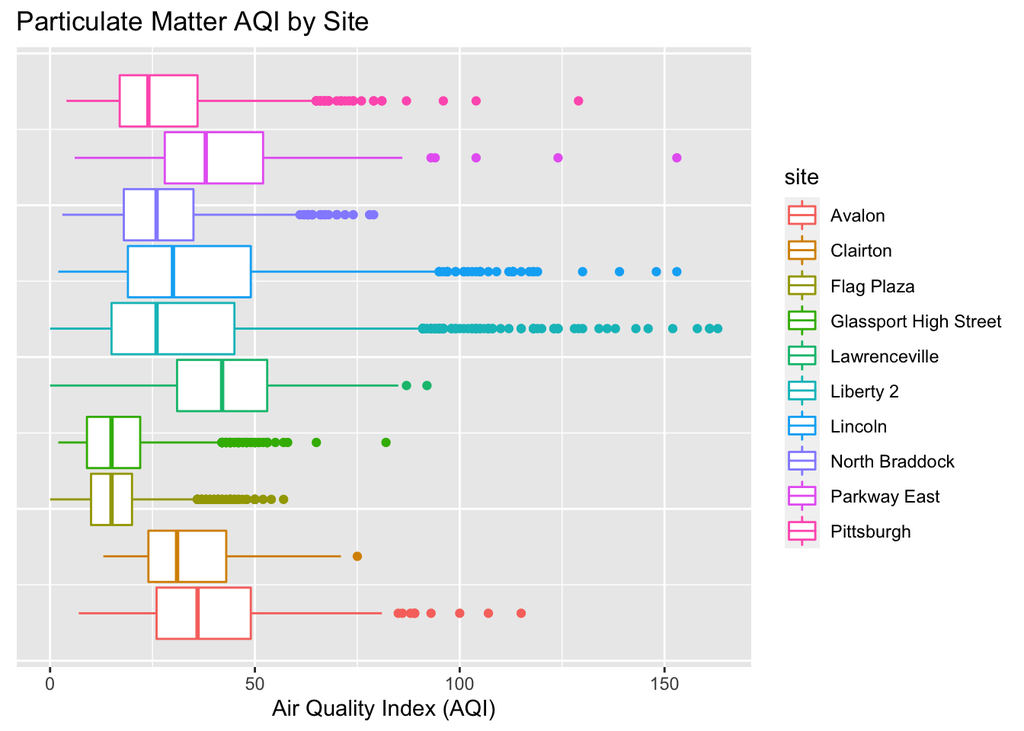

```r
ggplot(data = aqi.pm, aes(x = index_value, color = site)) +
  geom_boxplot() +
  theme(axis.text.y=element_blank(), axis.ticks.y=element_blank()) +  #Code to remove y axis ticks & text from https://www.statology.org/remove-axis-labels-ggplot2/
  labs(x = "Air Quality Index (AQI)", title = "Particulate Matter AQI by Site")
```

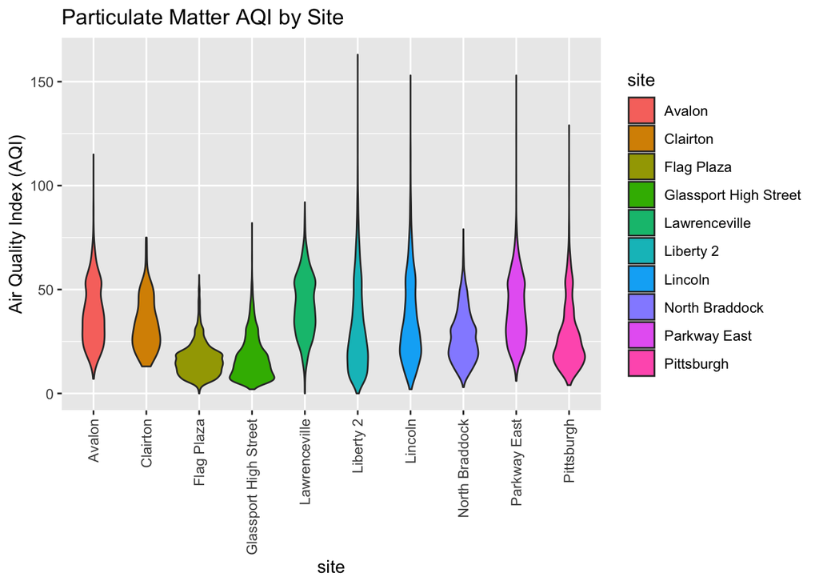

```r
qplot(x = site, y = index_value, data = aqi.pm, geom = "violin", fill = site) +
  theme(axis.text.x = element_text(angle = 90, vjust = 0.5, hjust=1)) +
  labs(y = "Air Quality Index (AQI)", title = "Particulate Matter AQI by Site")
```

```r
        #label adjustment code from https://stackoverflow.com/questions/1330989/rotating-and-spacing-axis-labels-in-ggplot2

#filter data for Ozone parameter
aqi.ozone <- aqi.AC %>%
  filter(parameter == "OZONE")
summary(aqi.ozone)
```

```
##       date                           site         parameter     index_value
##  Min.   :2016-01-01   Lawrenceville    :2430   OZONE   :7062   Min.   :  0.00
##  1st Qu.:2017-11-24   Harrison Township:2326   CO      :   0   1st Qu.: 29.00
##  Median :2019-07-14   South Fayette    :2306   NO2     :   0   Median : 36.00
##  Mean   :2019-07-01   Avalon           :   0   NO2_500 :   0   Mean   : 37.11
##  3rd Qu.:2021-02-23   Clairton         :   0   PM10    :   0   3rd Qu.: 44.00
##  Max.   :2022-10-05   Flag Plaza       :   0   PM10_640:   0   Max.   :129.00
##                       (Other)          :   0   (Other) :   0
##                          description
##  Good                          :6614
##  Moderate                      : 427
##  Unhealthy                     :   0
##  Unhealthy for Sensitive Groups:  21
##
##
##
##                                                                                                                                                          health_advisory
##                                                                                                                                                                  :6614
##  Active children and adults, and people with respiratory disease, such as asthma, should reduce prolonged or heavy outdoor exertion.                             :  21
##  People with asthma should consider limiting outdoor exertion.                                                                                                   :   0
##  People with heart or lung disease, older adults, and children should avoid prolonged or heavy exertion; everyone else should reduce prolonged or heavy exertion.:   0
##  People with heart or lung disease, older adults, and children should reduce prolonged or heavy exertion.                                                        :   0
##  Unusually sensitive people should consider reducing prolonged or heavy exertion.                                                                                :   0
##  Unusually sensitive people should consider reducing prolonged or heavy outdoor exertion.                                                                        : 427
##                                                                                                                                                                                        health_effects
##                                                                                                                                                                                               :6614
##  Increased aggravation of heart or lung disease and premature mortality in people with cardiopulmonary disease and older adults; increased respiratory effects in general population.         :   0
##  Increasing likelihood of respiratory symptoms and breathing discomfort in active children and adults and people with respiratory disease, such as asthma.                                    :  21
##  Increasing likelihood of respiratory symptoms in sensitive individuals, aggravation of heart or lung disease and premature mortality in people with cardiopulmonary disease and older adults.:   0
##  Increasing likelihood of respiratory symptoms, such as chest tightness and breathing discomfort, in people with asthma.                                                                      :   0
##  Respiratory symptoms possible in unusually sensitive individuals, possible aggravation of heart or lung disease in people with cardiopulmonary disease and older adults.                     :   0
##  Unusually sensitive individuals may experience respiratory symptoms.                                                                                                                         : 427
```

```r
str(aqi.ozone)
```

```
## 'data.frame':    7062 obs. of  7 variables:
##  $ date           : Date, format: "2016-01-01" "2016-01-01" ...
##  $ site           : Factor w/ 15 levels "Avalon","Clairton",..: 5 6 6 5 5 6 5 6 5 6 ...
##  $ parameter      : Factor w/ 13 levels "CO","NO2","NO2_500",..: 4 4 4 4 4 4 4 4 4 4 ...
##  $ index_value    : int  31 31 21 22 26 28 31 29 18 17 ...
##  $ description    : Factor w/ 4 levels "Good","Moderate",..: 1 1 1 1 1 1 1 1 1 1 ...
##  $ health_advisory: Factor w/ 7 levels "","Active children and adults, and people with respiratory disease, such as asthma, should reduce prolonged or hea"| __truncated__,..: 1 1 1 1 1 1 1 1 1 1 ...
##  $ health_effects : Factor w/ 7 levels "","Increased aggravation of heart or lung disease and premature mortality in people with cardiopulmonary disease a"| __truncated__,..: 1 1 1 1 1 1 1 1 1 1 ...
```

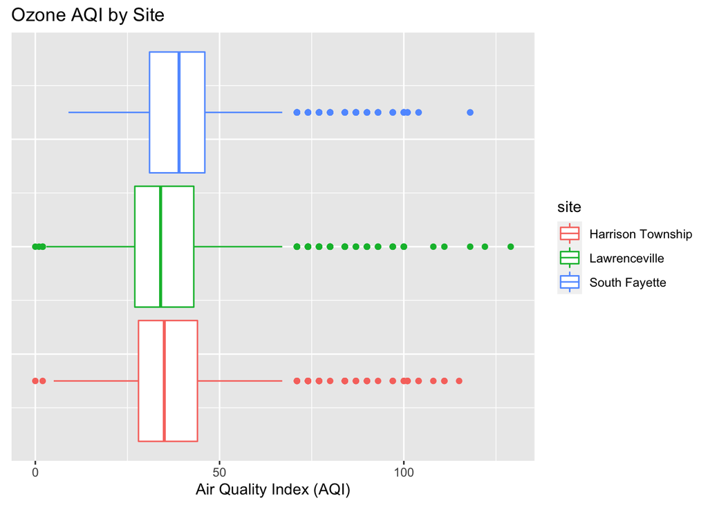

```r
ggplot(data = aqi.ozone, aes(x = index_value, color = site)) +
  geom_boxplot() +
  theme(axis.text.y=element_blank(), axis.ticks.y=element_blank()) +
  labs(x = "Air Quality Index (AQI)", title = "Ozone AQI by Site")
```

Above, I was able to filter the data for two specific pollutants: particulate matter and ozone. Because there are multiple varieties of particulate matter, there are more observations in the aqi.pm dataset than in the aqi.ozone dataset. There are 23390 observations of particulate matter, versus 7062 observations of ozone. When visualizing the spread of the index values by site, these plots also revealed that particulate matter is measured at more sites than ozone is, and there are more differences across sites.

### Observing Variable Characteristics

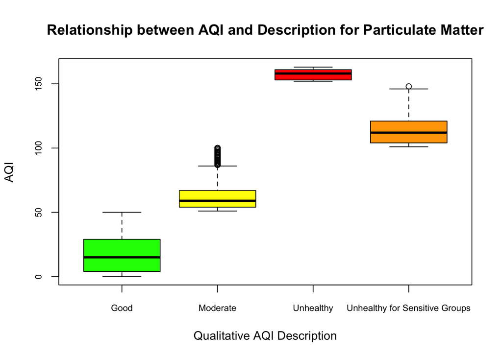

```r
description.colors <- c("green", "yellow", "red", "orange") #create color palette
boxplot(index_value ~ description, aqi.AC,
        xlab = "Qualitative AQI Description",
        ylab = "AQI",
        main = "Relationship between AQI and Description for Particulate Matter",
        col = description.colors,
        par(cex.axis= .75)) # code to resize labels for x-axis from https://stackoverflow.com/questions/10488310/increase-size-of-boxplot-names-in-r
```

```r
pm.description.summary <- aqi.pm %>%
  group_by(description) %>%
  summarize(mean = mean(index_value), st.dev. = sd(index_value),
            median = median(index_value),
            min = min(index_value), max = max(index_value))

knitr::kable(pm.description.summary, digits = 2)
```

| description | mean | st.dev. | median | min | max |
| --- | --- | --- | --- | --- | --- |
| Good | 24.63 | 11.94 | 23 | 0 | 50 |
| Moderate | 61.29 | 9.66 | 58 | 51 | 100 |
| Unhealthy | 157.29 | 4.57 | 158 | 152 | 163 |
| Unhealthy for Sensitive Groups | 115.23 | 12.12 | 113 | 101 | 148 |

These side-by-side boxplots confirm the intuition that lower AQI values are labeled “Good” and high AQI values are labeled “Unhealthy.” They also illustrate the ranges of index values that these descriptors apply to for particulate matter pollutants. The table describes summary information of index values for each description. Note that the mean particulate matter AQI described as “Good” is 24.63, while the mean particulate matter AQI described as “Unhealthy” is much higher at 157.29. The range of AQI values described as “Unhealthy” appears to be smallest.

## Looking for Trends

### Analysis by Season

Measuring air quality data over time is important for understanding what factors might affect pollution levels. One question I have is whether the time of year impacts air quality.

```r
#creating custom function to determine the season given the month
find_season <- function(date) {
  m <- month(date)
  case_when(m == 1 | m == 2 | m == 12 ~ "winter",   #referenced the "R Guide" from the Heinz class "Statistical Reasoning with
            m == 3 | m == 4 | m == 5 ~ "spring",    #R" [90711] with Amelia Haviland for example of case_when()
            m == 6 | m == 7 | m == 8 ~ "summer",
            m == 9 | m == 10 | m == 11 ~ "fall")
}

#add column for season
aqi.AC <- aqi.AC %>%
  mutate(season = find_season(date))

#test season column: successful
aqi.AC$season[30000] #summer
```

```
## [1] "summer"
```

```r
aqi.AC$date[30000] #august
```

```
## [1] "2019-08-22"
```

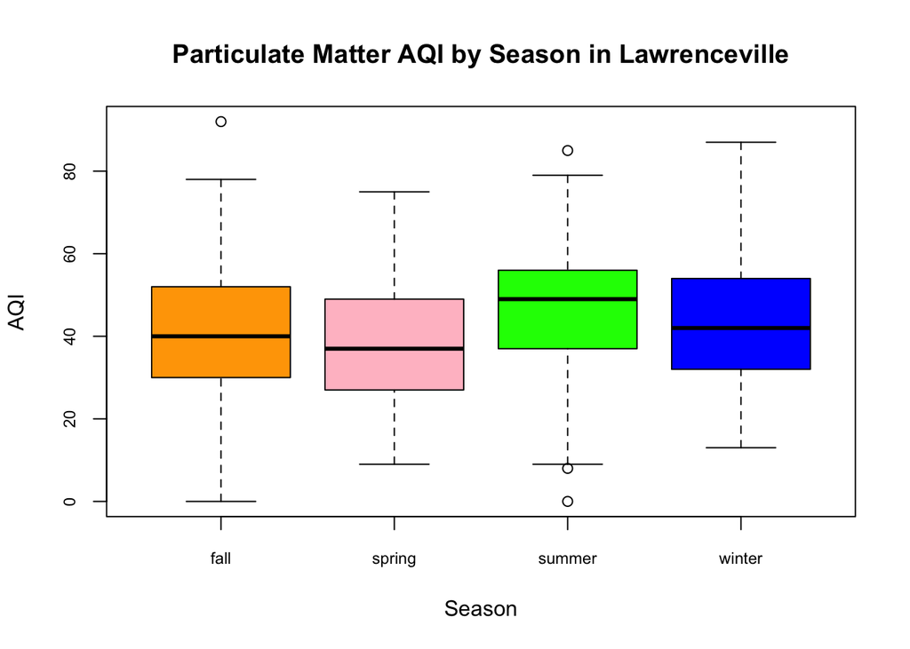

```r
#add season column to other dataframes
aqi.pm <- aqi.pm %>%
  mutate(season = find_season(date))
aqi.ozone <- aqi.pm %>%
  mutate(season = find_season(date))

#visualizing PM AQI by season for a specific site
#filter data to Lawrenceville site
aqi.lawrenceville.pm <- aqi.AC %>%
  filter(site == "Lawrenceville" |
         site == "Lawrenceville 2") %>%
  filter(grepl("PM", parameter))
#plot figure
season.colors <- c("orange","pink","green","blue")
boxplot(index_value ~ season, aqi.lawrenceville.pm,
        xlab = "Season",
        ylab = "AQI",
        main = "Particulate Matter AQI by Season in Lawrenceville",
        col = season.colors,
        par(cex.axis= .75))
```

At the Lawrenceville site, there appears to be some difference in AQI between seasons. Specifically, it appears that the mean AQI in summer is higher than that in the other three seasons. To investigate this possible trend, I will look at observations labeled as “Good” versus all other descriptions (including “Unhealthy,” “Moderate,” and “Unhealthy for Sensitive Groups.”)

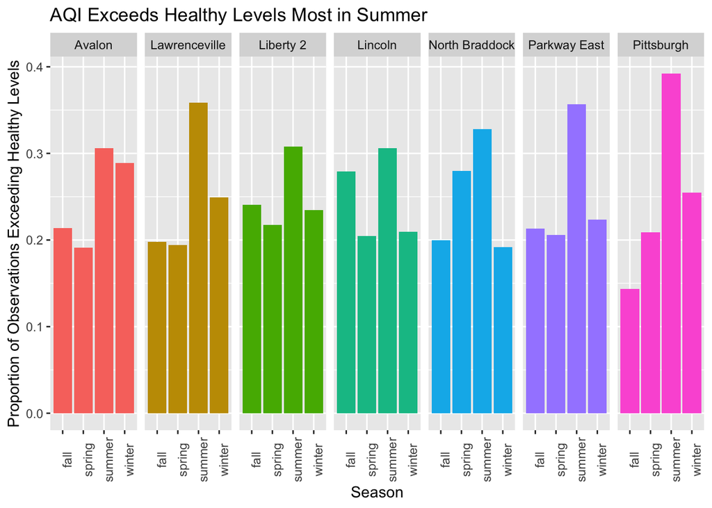

```r
#Creating figure to illustrate observations NOT described as "Good" by site and season
#add column to identify healthy AQI levels ("Good" as TRUE and all other descriptions as FALSE)
aqi.pm <- aqi.pm %>%
  mutate(healthy = description == "Good")

#creating ggplot object
season.site.plot <- aqi.pm %>%
  filter(healthy == FALSE) %>%
  filter(site != "Clairton",    #filtering out sites with missing seasons
         site != "Flag Plaza",
         site != "Glassport High Street") %>%
  ggplot(aes(x = season, y = ..prop.., fill = site, group = 1))
                                      #code for bar graph with proportions from
                                      #https://rstudio-pubs-static.s3.amazonaws.com/291083_2b0374fddc464ed08b4eb16c95d84075.html

#producing figure
season.site.plot + geom_bar(stat="count", position="dodge") +
  facet_grid(~site) +
  theme(axis.text.x = element_text(angle = 90)) +
  guides(fill = "none") +
  ylab("Proportion of Observations Exceeding Healthy Levels") +
  xlab("Season") +
  labs(title = "AQI Exceeds Healthy Levels Most in Summer")
```

Based on the figure above, there is a noticeable visual trend across sites: observations that exceed healthy AQI levels for particulate matter appear to increase in the summer season. To investigate this possible trend, I will perform further analysis on two specific sites: Pittsburgh and North Braddock.

```r
#filter data for Pittsburgh site
aqi.pm.pitt <- aqi.pm %>%
  filter(site == "Pittsburgh")
#perform ANOVA analysis
anova.pitt <- aov(healthy ~ season, data = aqi.pm.pitt)
summary(anova.pitt)
```

```
##               Df Sum Sq Mean Sq F value  Pr(>F)
## season         3   1.66  0.5539     5.2 0.00143 **
## Residuals   1245 132.60  0.1065
## ---
## Signif. codes:  0 '***' 0.001 '**' 0.01 '*' 0.05 '.' 0.1 ' ' 1
```

```r
#filter data for North Braddock site
aqi.pm.brad <- aqi.pm %>%
  filter(site == "North Braddock")
#perform ANOVA analysis
anova.brad <- aov(healthy ~ season, data = aqi.pm.brad)
summary(anova.brad)
```

```
##               Df Sum Sq Mean Sq F value Pr(>F)
## season         3   0.13 0.04292   0.948  0.417
## Residuals   2626 118.93 0.04529
```

**Pittsburgh site:** Based on the ANOVA analysis, the season does impact the AQI levels. The p-value from the ANOVA is less than alpha=0.05, indicating that there are statistically significant differences between the “healthy” AQI levels by season.

**North Braddock site:** Based on the ANOVA analysis, the season does not impact the AQI levels. The p-value from the ANOVA is greater than alpha=0.05, indicating that there is no statistical difference between these groups.

Further investigation is needed to analyze the potential trend of higher proportions of unhealthy AQI levels occuring in the summer season.

### Analysis by Month and Year

```r
#add column for year
aqi.AC <- aqi.AC %>%
  mutate(year = year(date))
aqi.pm <- aqi.pm %>%
  mutate(year = year(date))
aqi.lawrenceville.pm <- aqi.lawrenceville.pm %>%
  mutate(year = year(date))

#test year column
aqi.AC$year[30000] #2019
```

```
## [1] 2019
```

```r
aqi.AC$date[30000] # "2019-08-22"
```

```
## [1] "2019-08-22"
```

```r
#summarize PM AQI values by year
pm.years <- aqi.pm %>%
  group_by(year) %>%
  summarize(mean = mean(index_value),
            st.dev. = sd(index_value))
knitr::kable(pm.years, digits = 2)
```

| year | mean | st.dev. |
| --- | --- | --- |
| 2016 | 32.07 | 18.84 |
| 2017 | 32.29 | 19.58 |
| 2018 | 31.52 | 18.92 |
| 2019 | 32.83 | 19.07 |
| 2020 | 27.54 | 16.59 |
| 2021 | 29.94 | 18.30 |
| 2022 | 29.01 | 16.59 |

```r
#add column for month
aqi.AC <- aqi.AC %>%
  mutate(month = month(date))
aqi.pm <- aqi.pm %>%
  mutate(month = month(date))
aqi.lawrenceville.pm <- aqi.lawrenceville.pm %>%
  mutate(month = month(date))
#test month column
aqi.AC$month[30000] #8
```

```
## [1] 8
```

```r
aqi.AC$date[30000] # "2019-08-22"
```

```
## [1] "2019-08-22"
```

```r
#summarize AQI values by month
pm.months <- aqi.pm %>%
  group_by(month) %>%
  summarize(mean = mean(index_value),
            st.dev. = sd(index_value))
knitr::kable(pm.months, digits = 2)
```

| month | mean | st.dev. |
| --- | --- | --- |
| 1 | 29.01 | 19.22 |
| 2 | 29.96 | 19.14 |
| 3 | 28.30 | 17.93 |
| 4 | 27.27 | 16.65 |
| 5 | 29.68 | 17.43 |
| 6 | 33.24 | 17.03 |
| 7 | 35.89 | 17.91 |
| 8 | 33.93 | 16.61 |
| 9 | 30.93 | 17.89 |
| 10 | 28.33 | 17.47 |
| 11 | 32.52 | 20.89 |
| 12 | 30.87 | 21.43 |

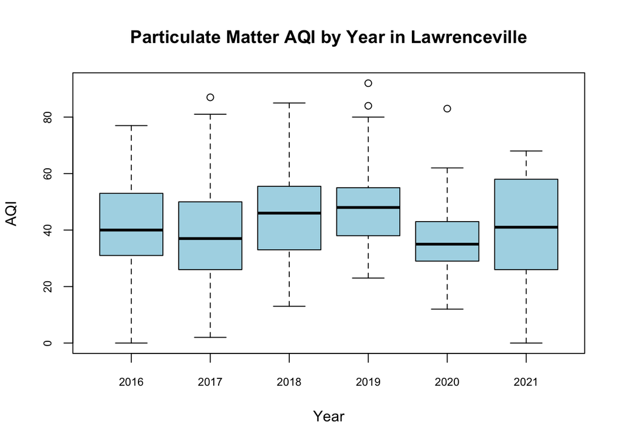

```r
#Lawrenceville site by year
boxplot(index_value ~ year, aqi.lawrenceville.pm,
        xlab = "Year",
        ylab = "AQI",
        main = "Particulate Matter AQI by Year in Lawrenceville",
        col = "light blue",
        par(cex.axis= .75))
```

The given tables describing particulate matter AQI by year and by month do not reveal any startlingly different values. The data appears to be relatively stable across months and across years. However, when zooming in on the Lawrenceville site, the boxplots visually suggest that there 2020 could have had lower index values than other years.

```r
#scatterplot over years with curve
```

### Analyzing impacts of COVID-19 pandemic on AQI

Based on the observations from the above plots, I wondered if pollutant levels were affected by the COVID-19 pandemic. To perform this analysis, I will focus on the Lawrenceville site. However, further analysis at different sites would be required to draw strong conclusions.

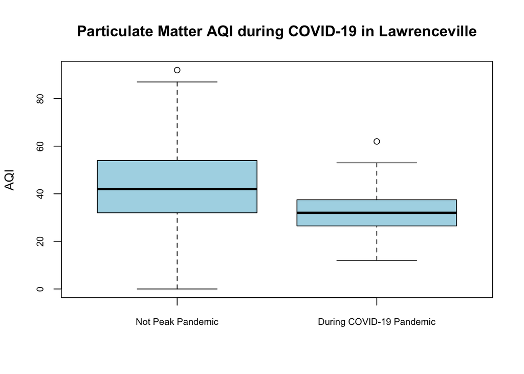

```r
#create dataframe for Lawrenceville "before covid"
aqi.lawrenceville.bc <- aqi.lawrenceville.pm %>%
  filter(date < "2020-03-14")
#create dataframe for Lawrenceville during the peak COVID year
aqi.lawrenceville.covid <- aqi.lawrenceville.pm %>%
  filter(date >= "2020-03-14" &
        date <= "2021-03-14")
#add column to lawrenceville dataframe indicating if the observation was taken during COVID
aqi.lawrenceville.pm <- aqi.lawrenceville.pm %>%
  mutate(COVID = date >= "2020-03-14" &
                date <= "2021-03-14")

#visualize AQI during COVID
boxplot(index_value ~ COVID, aqi.lawrenceville.pm,
        xlab = " ",
        ylab = "AQI",
        main = "Particulate Matter AQI during COVID-19 in Lawrenceville",
        col = "light blue",
        names = c("Not Peak Pandemic", "During COVID-19 Pandemic"),
        par(cex.axis= .75))
```

```r
#calculate mean and standard deviation
aqi.covid <- aqi.lawrenceville.pm %>%
  group_by(COVID) %>%
  summarize(mean = mean(index_value), st.dev.=sd(index_value))
knitr::kable(aqi.covid, digits = 2)
```

| COVID | mean | st.dev. |
| --- | --- | --- |
| FALSE | 42.71 | 14.56 |
| TRUE | 32.92 | 9.26 |

```r
#perform t test to compare means
t.test(aqi.lawrenceville.bc$index_value, aqi.lawrenceville.covid$index_value)
```

```
##
##  Welch Two Sample t-test
##
## data:  aqi.lawrenceville.bc$index_value and aqi.lawrenceville.covid$index_value
## t = 8.6571, df = 93.697, p-value = 1.342e-13
## alternative hypothesis: true difference in means is not equal to 0
## 95 percent confidence interval:
##   7.567474 12.072034
## sample estimates:
## mean of x mean of y
##  42.73975  32.92000
```

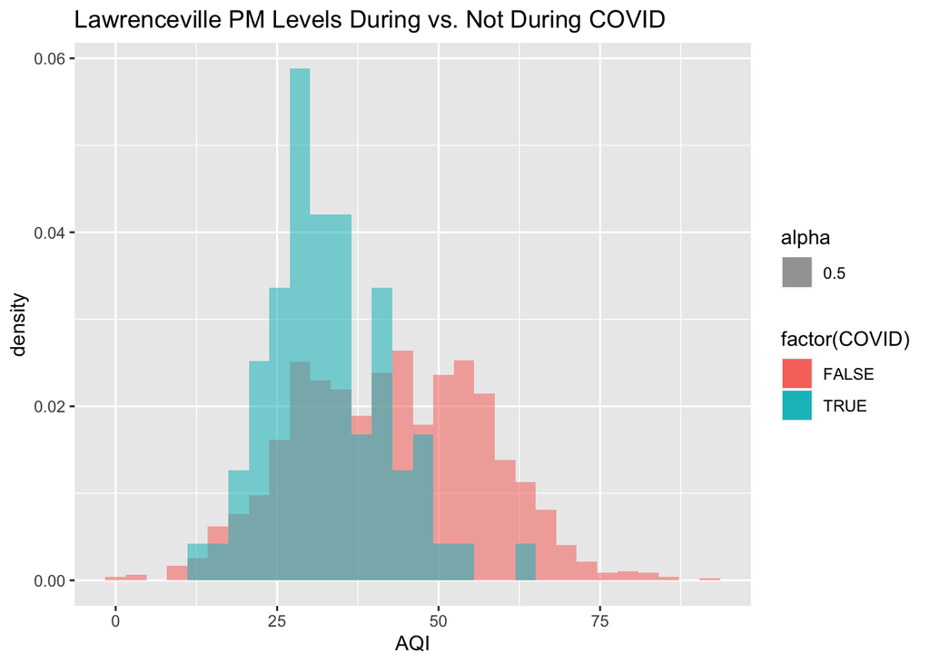

```r
aqi.lawrenceville.pm$year <- as.factor(aqi.lawrenceville.pm$year)

aqi.lawrenceville.pm %>%
  ggplot(aes(x = index_value, fill = factor(COVID), alpha = 0.5)) +
  geom_histogram(aes(y = ..density..), position = 'identity') +
  labs(title = "Lawrenceville PM Levels During vs. Not During COVID", x = "AQI")
```

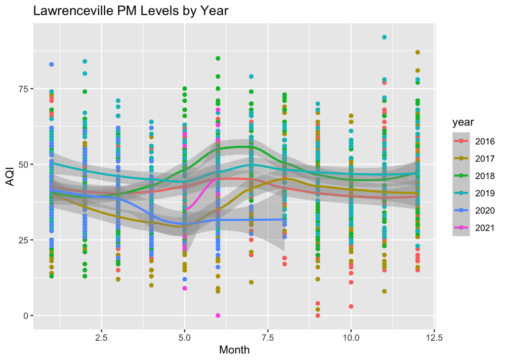

```r
plot.other <- aqi.lawrenceville.pm %>%
  ggplot(aes(x = month, y = index_value, color = year))

plot.other + geom_point() + stat_smooth() +
  labs(title = "Lawrenceville PM Levels by Year", x = "Month", y = "AQI")
```

Based on the visual differences between COVID times and non-COVID times in the boxplot and histogram, it appears that the pandemic did impact air quality. Specifically, it seemed that pollution levels decreased during the peak pandemic year. This could be explained by the shut-down that society experienced, which resulted in fewer cars on the road, and generally less commerce and industry.

To test the difference in means, I used a t test analysis. The results of the t test indicate that there is a statistically significant difference between AQI during peak pandemic, and AQI in other years, for particulate matter in Lawrenceville.

Finally, the scatterplot illustrates how AQI levels change across months for different years. While the 2020 data does not span all 12 months, it appears that beginning in April, the AQI levels decrease relative to most years. It should be noted that 2017 also experienced a dip at this time, but increased sooner than levels in 2020 did. Further investigation would be required to explain this dip during 2017. When the 2020 data cuts off during the summer, it appears that AQI levels were remaining low relative to trends of past years.